# Tarea Programada 02

Yelena Hernandez - Carné: C33676

2026-06-17

## Carga, exploración y calidad de datos

### 1. Cargar los paquetes requeridos y las tablas flights, airlines, airports, planes y weather.

```r
#En el html se ve mal esteticamente

flights <- flights
airlines <- airlines
airports <- airports
planes <- planes
weather <- weather

dim(flights)
```

```
## [1] 336776     19
```

```r
dim(airlines)
```

```
## [1] 16  2
```

```r
dim(airports)
```

```
## [1] 1458    8
```

```r
dim(planes)
```

```
## [1] 3322    9
```

```r
dim(weather)
```

```
## [1] 26115    15
```

```r
head(flights,4)
```

```
## # A tibble: 4 × 19
##    year month   day dep_time sched_dep_time dep_delay arr_time sched_arr_time
##   <int> <int> <int>    <int>          <int>     <dbl>    <int>          <int>
## 1  2013     1     1      517            515         2      830            819
## 2  2013     1     1      533            529         4      850            830
## 3  2013     1     1      542            540         2      923            850
## 4  2013     1     1      544            545        -1     1004           1022
## # ℹ 11 more variables: arr_delay <dbl>, carrier <chr>, flight <int>,
## #   tailnum <chr>, origin <chr>, dest <chr>, air_time <dbl>, distance <dbl>,
## #   hour <dbl>, minute <dbl>, time_hour <dttm>
```

```r
head(airlines,4)
```

```
## # A tibble: 4 × 2
##   carrier name
##   <chr>   <chr>
## 1 9E      Endeavor Air Inc.
## 2 AA      American Airlines Inc.
## 3 AS      Alaska Airlines Inc.
## 4 B6      JetBlue Airways
```

```r
head(airports,4)
```

```
## # A tibble: 4 × 8
##   faa   name                            lat   lon   alt    tz dst   tzone
##   <chr> <chr>                         <dbl> <dbl> <dbl> <dbl> <chr> <chr>
## 1 04G   Lansdowne Airport              41.1 -80.6  1044    -5 A     America/New…
## 2 06A   Moton Field Municipal Airport  32.5 -85.7   264    -6 A     America/Chi…
## 3 06C   Schaumburg Regional            42.0 -88.1   801    -6 A     America/Chi…
## 4 06N   Randall Airport                41.4 -74.4   523    -5 A     America/New…
```

```r
head(planes,4)
```

```
## # A tibble: 4 × 9
##   tailnum  year type               manufacturer model engines seats speed engine
##   <chr>   <int> <chr>              <chr>        <chr>   <int> <int> <int> <chr>
## 1 N10156   2004 Fixed wing multi … EMBRAER      EMB-…       2    55    NA Turbo…
## 2 N102UW   1998 Fixed wing multi … AIRBUS INDU… A320…       2   182    NA Turbo…
## 3 N103US   1999 Fixed wing multi … AIRBUS INDU… A320…       2   182    NA Turbo…
## 4 N104UW   1999 Fixed wing multi … AIRBUS INDU… A320…       2   182    NA Turbo…
```

```r
head(weather,4)
```

```
## # A tibble: 4 × 15
##   origin  year month   day  hour  temp  dewp humid wind_dir wind_speed wind_gust
##   <chr>  <int> <int> <int> <int> <dbl> <dbl> <dbl>    <dbl>      <dbl>     <dbl>
## 1 EWR     2013     1     1     1  39.0  26.1  59.4      270      10.4         NA
## 2 EWR     2013     1     1     2  39.0  27.0  61.6      250       8.06        NA
## 3 EWR     2013     1     1     3  39.0  28.0  64.4      240      11.5         NA
## 4 EWR     2013     1     1     4  39.9  28.0  62.2      250      12.7         NA
## # ℹ 4 more variables: precip <dbl>, pressure <dbl>, visib <dbl>,
## #   time_hour <dttm>
```

### 2. Vista paginada de las primeras 100 observaciones de flights con 10 observaciones por página. No debe incorporar la tabla completa en el HTML.

```
## # A tibble: 10 × 19
##     year month   day dep_time sched_dep_time dep_delay arr_time sched_arr_time
##    <int> <int> <int>    <int>          <int>     <dbl>    <int>          <int>
##  1  2013     1     1      517            515         2      830            819
##  2  2013     1     1      533            529         4      850            830
##  3  2013     1     1      542            540         2      923            850
##  4  2013     1     1      544            545        -1     1004           1022
##  5  2013     1     1      554            600        -6      812            837
##  6  2013     1     1      554            558        -4      740            728
##  7  2013     1     1      555            600        -5      913            854
##  8  2013     1     1      557            600        -3      709            723
##  9  2013     1     1      557            600        -3      838            846
## 10  2013     1     1      558            600        -2      753            745
## # ℹ 11 more variables: arr_delay <dbl>, carrier <chr>, flight <int>,
## #   tailnum <chr>, origin <chr>, dest <chr>, air_time <dbl>, distance <dbl>,
## #   hour <dbl>, minute <dbl>, time_hour <dttm>
```

[output not shown]

### 4. Identificar y presentar la cantidad y el porcentaje de valores faltantes en las variables principales de flights: dep_time, dep_delay, arr_time, arr_delay y tailnum.

```
## # A tibble: 1 × 10
##   dep_time_na dep_time_por dep_delay_na dep_delay_por arr_time_na arr_time_por
##         <int>        <dbl>        <int>         <dbl>       <int>        <dbl>
## 1        8255         2.45         8255          2.45        8713         2.59
## # ℹ 4 more variables: arr_delay_na <int>, arr_delay_por <dbl>,
## #   tailnum_na <int>, tailnum_por <dbl>
```

### 5. Crear al menos las variables derivadas fecha, cancelado y retraso_llegada, donde un vuelo se considere retrasado cuando llegue con más de 15 minutos de retraso. Debe explicar cómo trató los valores faltantes.

```r
#Fecha
flights2 <- flights %>%
  mutate( fecha = as.Date( paste(year, month, day, sep = "-")
    ))

#Cancelados
flights2 <- flights2 %>%
  mutate(cancelado = is.na(dep_time))

#Retraso de llagada
flights2 <- flights2 %>%
  mutate( retraso_llegada =  if_else(
        arr_delay > 15, "Retrasado", "A tiempo", missing = NA))
```

La variable fecha se construyó a partir de las variables year, month y day, las cuales no presentan valores faltantes. Para la variable cancelado, se consideró que un vuelo está cancelado cuando dep_time es NA. En la variable retraso_llegada, los vuelos con arr_delay > 15 se clasifican como retrasados. Cuando arr_delay es NA, el resultado se mantiene como NA debido a que no existe información suficiente para determinar si el vuelo llegó con retraso. Esto evita clasificar incorrectamente vuelos cancelados o con información incompleta.

## Integración y preparación de datos

```r
vuelos_analisis <- flights2 %>%
  left_join( airlines, by = "carrier")

vuelos_analisis <- flights2 %>%
  left_join( airports, by = c ("dest" = "faa"))

vuelos_analisis <- vuelos_analisis %>%
  left_join(weather, by = c("origin","year","month", "day", "hour"))

vuelos_analisis <- vuelos_analisis %>%
  left_join(planes, by = "tailnum")
```

```r
nrow(flights2)
```

```
## [1] 336776
```

```r
nrow(vuelos_analisis)
```

```
## [1] 336776
```

```r
sum(is.na(vuelos_analisis))
```

```
## [1] 1134596
```

```r
# sum(is.na(vuelos_analisis$year.y))

colSums(is.na(vuelos_analisis))
```

```
##          year.x           month             day        dep_time  sched_dep_time
##               0               0               0            8255               0
##       dep_delay        arr_time  sched_arr_time       arr_delay         carrier
##            8255            8713               0            9430               0
##          flight         tailnum          origin            dest        air_time
##               0            2512               0               0            9430
##        distance            hour          minute     time_hour.x           fecha
##               0               0               0               0               0
##       cancelado retraso_llegada            name             lat             lon
##               0            9430            7602            7602            7602
##             alt              tz             dst           tzone            temp
##            7602            7602            7602            7602            1573
##            dewp           humid        wind_dir      wind_speed       wind_gust
##            1573            1573            9796            1634          256391
##          precip        pressure           visib     time_hour.y          year.y
##            1556           38788            1556            1556           57912
##            type    manufacturer           model         engines           seats
##           52606           52606           52606           52606           52606
##           speed          engine
##          335813           52606
```

### Versión depurada de los datos

```r
vuelos_limpios <- vuelos_analisis %>%
  filter( !is.na(dep_delay), !is.na(arr_delay), !is.na(year.y)) %>%
  select(-speed)

cat("Filas originales:", nrow(vuelos_analisis), "\n")
```

```
## Filas originales: 336776
```

```r
cat("Filas depuradas:", nrow(vuelos_limpios), "\n")
```

```
## Filas depuradas: 273853
```

## Visualización de datos

### Grafico 1

```
## `geom_line()`: Each group consists of only one observation.
## ℹ Do you need to adjust the group aesthetic?
```

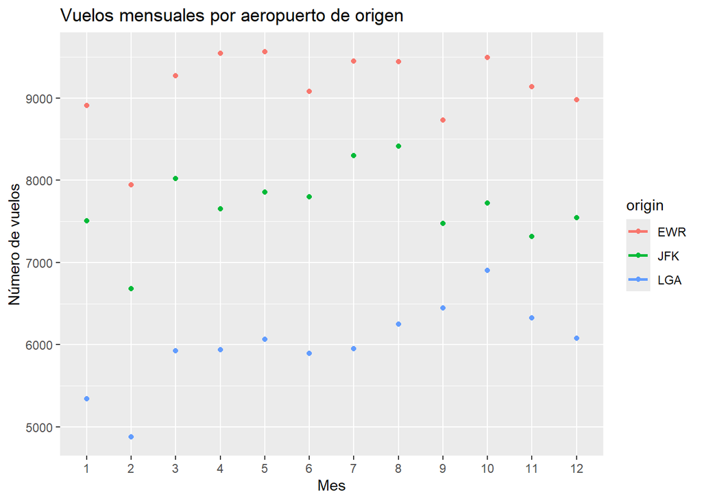

### Grafico 2

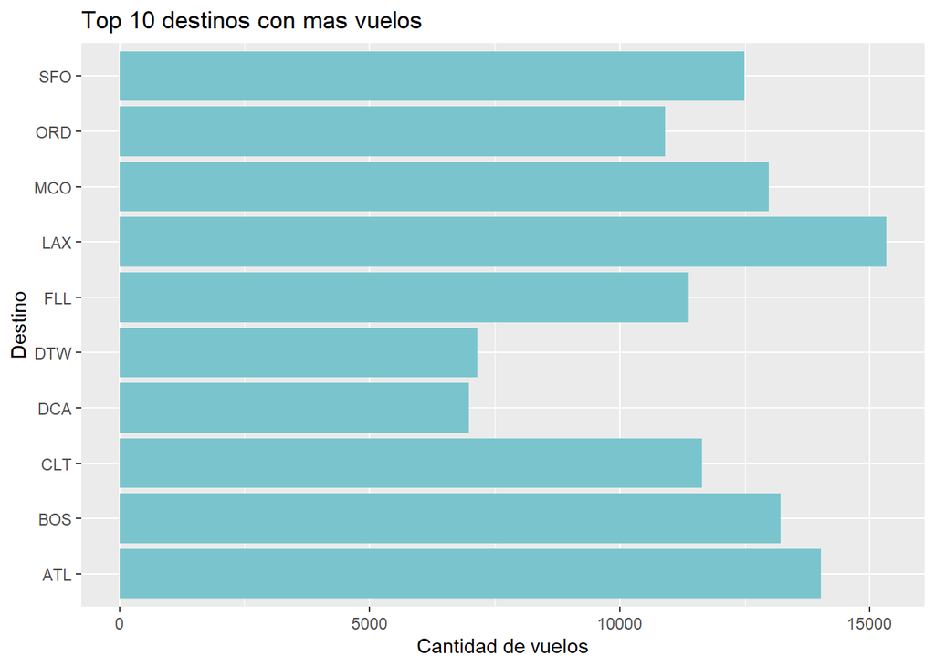

### Grafico 3

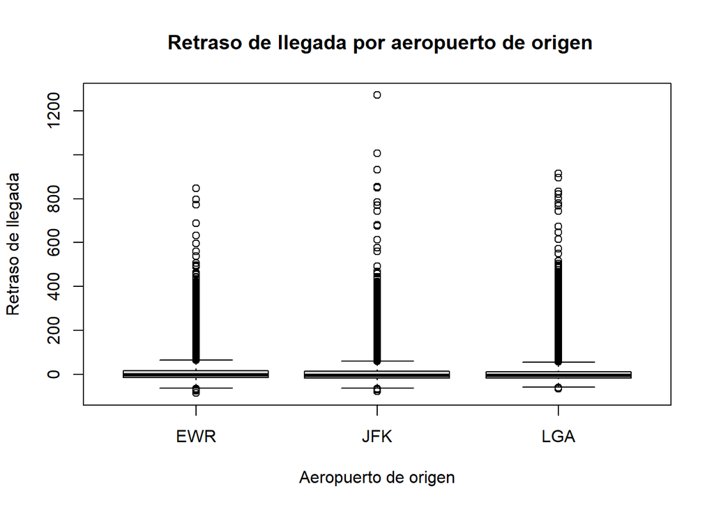

### Grafico 4

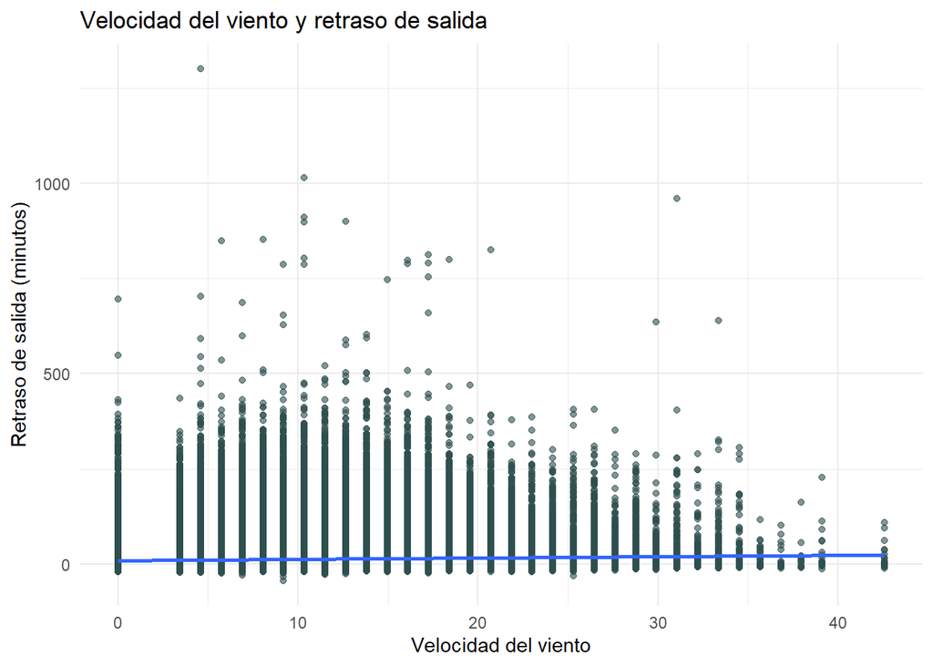

Decidi usar la variable wind_speed() ya que las condiciones del viento pueden afectar el despegue y aterrizaje del avion

### Grafico 5

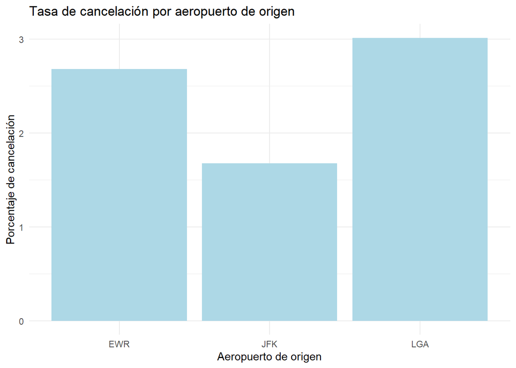

## Estadística descriptiva

### 1. Medidas para arr_delay

Estadísticas de arr_delay

| Media | Mediana | Varianza | Desv_Estandar | N |
| --- | --- | --- | --- | --- |
| 7.04 | -5 | 2018.68 | 44.93 | 273853 |

| carrier | name | vuelos | cancelacion_por | media_retraso | mediana_retraso |
| --- | --- | --- | --- | --- | --- |
| DL | Hartsfield Jackson Atlanta Intl | 10571 | 0.87 | 7.42 | -4.0 |
| US | Charlotte Douglas Intl | 8632 | 1.44 | 2.44 | -5.0 |
| AA | Dallas Fort Worth Intl | 7257 | 3.28 | -0.49 | -10.0 |
| AA | Miami Intl | 7234 | 0.87 | -1.88 | -10.0 |
| UA | Chicago Ohare Intl | 6984 | 3.02 | 6.07 | -7.0 |
| UA | George Bush Intercontinental | 6924 | 1.34 | 3.73 | -5.0 |
| UA | San Francisco Intl | 6819 | 0.84 | 3.14 | -6.0 |
| B6 | Fort Lauderdale Hollywood Intl | 6563 | 1.17 | 11.97 | -1.0 |
| B6 | Orlando Intl | 6472 | 0.88 | 11.55 | -1.0 |
| AA | Chicago Ohare Intl | 6059 | 3.10 | -0.71 | -12.0 |
| UA | Los Angeles Intl | 5823 | 0.69 | 2.92 | -5.0 |
| MQ | Raleigh Durham Intl | 4794 | 5.01 | 8.82 | -2.0 |
| US | Ronald Reagan Washington Natl | 4716 | 4.86 | 5.84 | -3.0 |
| B6 | General Edward Lawrence Logan Intl | 4383 | 1.25 | 7.89 | -7.0 |
| US | General Edward Lawrence Logan Intl | 4283 | 6.33 | -2.42 | -9.0 |
| WN | Chicago Midway Intl | 4113 | 1.68 | 12.36 | -1.0 |
| EV | Washington Dulles Intl | 4048 | 5.41 | 15.48 | -2.0 |
| DL | Detroit Metro Wayne Co | 3875 | 0.90 | 0.74 | -9.0 |
| UA | Denver Intl | 3796 | 1.03 | 5.16 | -5.0 |
| B6 | NA | 3695 | 0.57 | 7.80 | -2.0 |
| DL | Orlando Intl | 3663 | 0.52 | 0.90 | -9.0 |
| AA | Los Angeles Intl | 3582 | 0.70 | -1.64 | -10.0 |
| UA | General Edward Lawrence Logan Intl | 3342 | 1.26 | 4.07 | -9.0 |
| UA | Orlando Intl | 3217 | 0.62 | -0.81 | -8.0 |
| B6 | Palm Beach Intl | 3161 | 1.01 | 13.90 | 1.0 |
| DL | Miami Intl | 2929 | 0.65 | 2.27 | -9.0 |
| DL | Fort Lauderdale Hollywood Intl | 2903 | 0.79 | 2.32 | -7.0 |
| DL | Minneapolis St Paul Intl | 2864 | 0.94 | 4.04 | -8.0 |
| B6 | Buffalo Niagara Intl | 2803 | 1.03 | 9.80 | -4.0 |
| B6 | Tampa Intl | 2800 | 0.93 | 14.17 | 1.0 |

[output cut: 278 more lines]

**Interpretacion:** Los resultados muestran que algunos destinos concentran una mayor cantidad de vuelos, destacando Hartsfield Jackson Atlanta International y Charlotte Douglas International. En general, los porcentajes de cancelación son bajos, aunque algunos aeropuertos presentan valores superiores al promedio. Además, la mayoría de las medianas de retraso son negativas, lo que indica que más de la mitad de los vuelos llegaron puntualmente o antes de lo programado, aunque algunos retrasos elevados incrementan el promedio en ciertos destinos.

### 3. Tabla de contingencia entre origin y cancelado, acompañada de

porcentajes que permitan comparar adecuadamente los aeropuertos.

Porcentajes de vuelos cancelados por aeropuerto

| origin | total_vuelos | vuelos_cancelados | porcentaje_cancelados |
| --- | --- | --- | --- |
| EWR | 120835 | 3239 | 2.68 |
| JFK | 111279 | 1863 | 1.67 |
| LGA | 104662 | 3153 | 3.01 |

### 4. Seleccionar una tabla o visualización adicional que resuma un hallazgo relevante del proceso de integración con datos meteorológicos o de aeronaves.

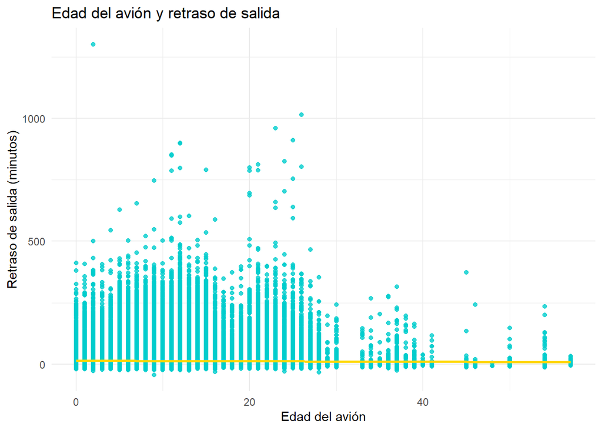

**Hallazgo:** El gráfico muestra la relación entre la edad del avión y el retraso de salida, se ve que los puntos están bastante dispersos y no se observa un patrón claro que indique que los aviones más antiguos tengan mayores retrasos. La línea de tendencia es casi horizontal, lo que sugiere que la edad del avión no tiene una relación fuerte con el retraso de salida.